# e5_12

## Exercise 5.12

The goal of this exercise is to train a race car to reach the finish line in a gride world. The car can only control its acceleration. It can accelerate the forward, backward and side to side at one-pixel per-step. However, this acceleration is not guaranteed. With a 10% chance, the car fails to accelerate at all on any given step. For this exercise, since I was having trouble with plotters, I made a command-line interface for the rust code [here](https://github.com/levmckinney/RL2018/tree/master/exercises/chapter5/e5_12). So first we have to build that:

```python
!(cd e5_12 && cargo build --release)
```

```
   Compiling e5_12 v0.1.0 (/workspaces/RL2018/exercises/chapter5/e5_12)
    Finished release [optimized] target(s) in 2.56s===============> ] 86/87
```

## Starting with a small track

The track used here is similar to the one shown in the textbook. I found that off policy Monte Carlo worked the best with an epsilon greedy behaviour policy and a greedy target policy. Importance sampling is used to account for the different target and behaviour policies. It's run this for 2,000,000 episodes. This will generally learn a good policy however rarely the greedy policy will become to sit still on the start line. I'm still trying to work out exactly why it does this.

```python
%%capture
# --vel-limits 0 5 -5 0 => only allow car to go up and to the right at velocity at most 5
# --no-stop => the car can only be still on the start line
# --example .. => save example trajectory with skidding turned off
# --value ... => image representing the average value of each pixel and save it
!./e5_12/target/release/main --track ./e5_12_tracks/race_track.png \
    --algo off-policy \
    --epsilon 0.5 \
    --num_episodes 2000000 \
    --vel-limits 0 5 -5 0 \
    --no-stop \
    --seed 42 \
    --example ./e5_12_outputs/race_track_off-policy_example.png \
    --value 0 5 -5 0 ./e5_12_outputs/race_track_off-policy_avg_value.png
```

#### Example Path

Starting at one of the red start states, we can see an example of the path to the green goal states. This is with the random acceleration freezes turned off.

```python
from IPython.display import Image
Image("/workspaces/RL2018/exercises/chapter5/e5_12_outputs/race_track_off-policy_example.png", width=400)
```

[output not shown]

#### Value function in range [-5000001, -1587308.061128042]

Bellow is the average value of each possition on the track. We ignore states where the car is not moving up and to the right to decrease the noise a bit. Howerver becuase we are only covering a small fraction of the full state space during the monte carlo simulations take this value funciton with a large grain of salt.

```python
from IPython.display import Image
Image("/workspaces/RL2018/exercises/chapter5/e5_12_outputs/race_track_off-policy_avg_value.png", width=400)
```

[output not shown]

### Exploring Starts

I did implement a second simpler algorithm for this problem, which was on policy Monte Carlo learning a greedy policy with exploring starts. Since this algorithm always follows a greedy policy, it can have a bit of trouble getting started and is highly sensitive to the initial value given to each state. In general, I have found that it is quite a bit slower and can become unrecoverably struct. Hence the low max episode length. However, the exploring starts method covers more of the state space than the off-policy method with small epsilon.

```python
%%capture
!./e5_12/target/release/main --track ./e5_12_tracks/race_track.png \
    --algo exploring \
    --num_episodes 2000000 \
    --max_ep_len 2000 \
    --vel-limits 0 5 -5 0 \
    --no-stop \
    --seed 42 \
    --example ./e5_12_outputs/race_track_exploring_example.png \
    --value 0 5 -5 0 ./e5_12_outputs/race_track_exploring_avg_value.png
```

#### Example path

Again a sample path following the optimal policy.

```python
from IPython.display import Image
Image("/workspaces/RL2018/exercises/chapter5/e5_12_outputs/race_track_exploring_example.png", width=400)
```

[output not shown]

#### Value function in range [-864.3870353363862, -6.588688817940989]

This was computed using the exact same method as the above value function.

```python
from IPython.display import Image
Image("/workspaces/RL2018/exercises/chapter5/e5_12_outputs/race_track_exploring_avg_value.png", width=400)
```

[output not shown]

## A Larger Example

Using the off-policy method, we can move to an even larger state space than seen in the textbook. This problem requires careful hyperparameter tunning and a longer run of 6,000,000 episodes to get reliable convergence.

```python
%%capture
!./e5_12/target/release/main --track ./e5_12_tracks/complex_track.png \
    --algo off-policy \
    --epsilon 0.08 \
    --seed 42 \
    --no-stop \
    --num_episodes 6000000 \
    --example ./e5_12_outputs/complex_track_off-policy_example.png \
    --value 0 10 -10 10 ./e5_12_outputs/complex_track_off-policy_avg_value.png
```

#### Example path

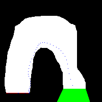

```python
from IPython.display import Image
Image("/workspaces/RL2018/exercises/chapter5/e5_12_outputs/complex_track_off-policy_example.png", width=400)
```

#### Value funciton [-5000001, -4206353.876426099]

Note here I include states moving downward in the average as well.

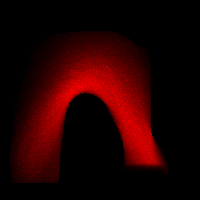

```python
from IPython.display import Image
Image("/workspaces/RL2018/exercises/chapter5/e5_12_outputs/complex_track_off-policy_avg_value.png", width=400)
```

#### Exploring Starts

This algorithm seems to be defeated by the larger state space. However, there may simply be a bug in this implementation that I have not found yet.